# Plot pareto chart and pyramid graph using ggplot2 in R.

Take home exercise 1 (two tasks) for ISSS608 Visual Analytics and Applications

Zhou Yiou https://example.com/norajones (MITB SMU)https://example.com/spacelysprokets  
2022-01-28

# **Task 1**

## Plot pareto chart

```r
orders <- read_xls("data/Superstore-2021.xls",
                  sheet = "Orders")
returns <- read_xls("data/Superstore-2021.xls",
                  sheet = "Returns")

# join orders table and returns table
joined_tab <- left_join(returns, orders,
                        by = c('Order ID' = 'Order ID'))
# compute the frequency of returns in regard of different sub-categories
# method 1 group_by()
freq_returned <- joined_tab %>%
  group_by(`Sub-Category`) %>%
  summarise('Returns' = n()) %>%
  ungroup()
# sort the data set in descending order
freq_sorted <- freq_returned %>%
  arrange(desc(Returns))
# Computing the cumulative frequency

# compute the cumulative frequency of returns by product sub-category. This task will be performed by using `mutate()` of dplyr package and cumsum() of Base R.
freq_cum <- freq_sorted %>%
  mutate(cumfreq = cumsum(Returns))

# check the structure and content of the tibble data frame
str(freq_cum)
```

```
tibble [17 x 3] (S3: tbl_df/tbl/data.frame)
 $ Sub-Category: chr [1:17] "Binders" "Paper" "Phones" "Furnishings" ...
 $ Returns     : int [1:17] 552 487 309 266 251 238 233 177 177 116 ...
 $ cumfreq     : int [1:17] 552 1039 1348 1614 1865 2103 2336 2513 2690 2806 ...
```

1. sort data first by **returns** then by **sub-category**
2. plot the Pareto graph in *three* steps:  
   1).plot the number of returns in points: `geom_points(y = cumfreq)`  
   2).connect the points: `geom_path(y = cumfreq)`  
   3).plot second y axis using the `sec.axis` argument in `scale_y_continuous`. Create the percentage by define the total return using `max(freq_cum$cumfreq)`
3. adjust the *ticks* on the *x-axis* using `theme(axis,te.x = element_text())`, set angle argument to 90

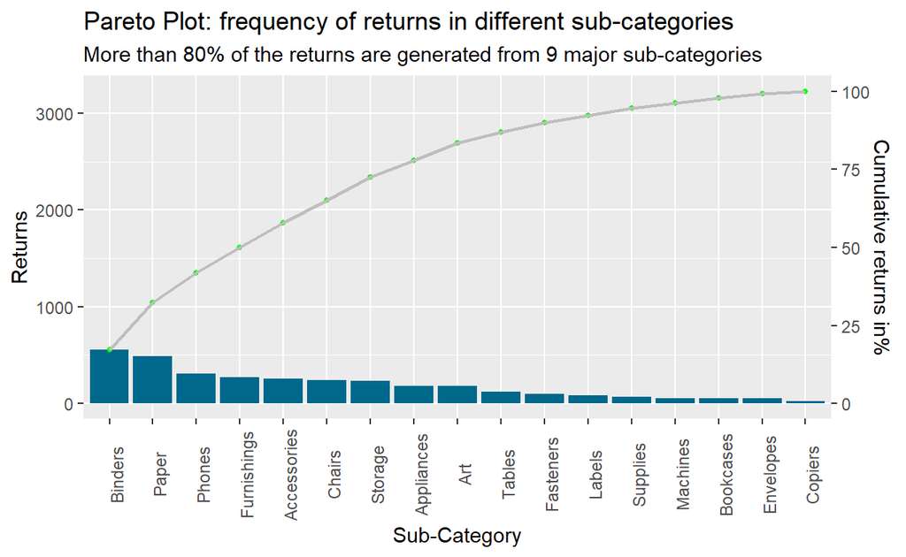

```r
total_return <- max(freq_cum$cumfreq)
pareto_cum <- ggplot(data = freq_cum, aes(x = reorder(`Sub-Category`, -Returns), y = Returns)) +
  geom_bar(aes(y = Returns),fill = 'deepskyblue4', stat = 'identity') +
  geom_point(aes(y = cumfreq), color = rgb(0,1,0), pch = 16, size = 1) +
  geom_line(aes(y = cumfreq, group = 1), color = "grey", lty = 1, size = 0.8) +
  scale_y_continuous(sec.axis = sec_axis(~(./total_return)*100, name = "Cumulative returns in%")) +
  labs(title = "Pareto Plot: frequency of returns in different sub-categories", subtitle = "More than 80% of the returns are generated from 9 major sub-categories", x = 'Sub-Category') +
  theme(axis.text.x = element_text(angle = 90))
pareto_cum
```

### Tableau vs. R (ggplot2) in regard of data visualization

Tableau is great for basic data exploration, visualization, and processing - table join, filter, etc., is very straightforward, relatively comprehensive, and interactive. Whereas, R is a language rather than software that encourages the users to write their scripts or find appropriate libraries to conduct the analysis, such as ggplot2. R provides more flexibility than Tableau regarding the type of visualization the users can generate. Tableau is more hands-on and straightforward for data exploration and visualization, but one might also face the risk of being locked into a single product. In contrast, R is more flexible yet requires more effort to generate interactive charts. However, users can easily export them into PNG or even web apps.

# **Task 2**

## Create a pyramid graph using ggplot2

- A age-sex pyramid showing the demographic structure of Singapore by age cohort and gender.

### Data Import

Importing data-set using `read_csv()` of `readr` package, useful for reading delimited files into a `tibble`

```r
# Reading the csv file as a tbl_df
df_pop <- read_csv("data/respopagesextod2011to2020.csv")
# Inspecting the structure of the data-set
str(df_pop)
```

```
spec_tbl_df [984,656 x 7] (S3: spec_tbl_df/tbl_df/tbl/data.frame)
 $ PA  : chr [1:984656] "Ang Mo Kio" "Ang Mo Kio" "Ang Mo Kio" "Ang Mo Kio" ...
 $ SZ  : chr [1:984656] "Ang Mo Kio Town Centre" "Ang Mo Kio Town Centre" "Ang Mo Kio Town Centre" "Ang Mo Kio Town Centre" ...
 $ AG  : chr [1:984656] "0_to_4" "0_to_4" "0_to_4" "0_to_4" ...
 $ Sex : chr [1:984656] "Males" "Males" "Males" "Males" ...
 $ TOD : chr [1:984656] "HDB 1- and 2-Room Flats" "HDB 3-Room Flats" "HDB 4-Room Flats" "HDB 5-Room and Executive Flats" ...
 $ Pop : num [1:984656] 0 10 30 50 0 0 40 0 0 10 ...
 $ Time: num [1:984656] 2011 2011 2011 2011 2011 ...
 - attr(*, "spec")=
  .. cols(
  ..   PA = col_character(),
  ..   SZ = col_character(),
  ..   AG = col_character(),
  ..   Sex = col_character(),
  ..   TOD = col_character(),
  ..   Pop = col_double(),
  ..   Time = col_double()
  .. )
 - attr(*, "problems")=<externalptr>
```

### Data Wrangling

Select the columns that would be useful for data wrangling, rename for more intuitive ones from ‘AG’, ‘Pop’ and ‘Time’ to ‘Age_Group’, ‘Population’ and ‘Year’, respectively.

```r
df_pop <- df_pop %>%
  rename('Age_Group'='AG',
         'Population'='Pop',
         'Year' = 'Time')
# verify if the columns have been renamed correctly
colnames(df_pop)
```

```
[1] "PA"         "SZ"         "Age_Group"  "Sex"        "TOD"
[6] "Population" "Year"
```

TOD (Type of Dwelling),Planning_Area and Year will not be used in the visualization, therefore it is necessary to aggregate the population measure excluding those levels of detail. This can be achieved by using `group_by` and `summaries` functions from the `dplyr` package to sum up population by *Sex* and *Age_Group*.

```r
agg_pop <- df_pop %>%
  select(c("Sex", "Age_Group","Population")) %>%
  group_by(Sex,Age_Group) %>%
  summarise(Population=sum(Population))
head(agg_pop)
```

```
# A tibble: 6 x 3
# Groups:   Sex [1]
  Sex     Age_Group Population
  <chr>   <chr>          <dbl>
1 Females 0_to_4        907380
2 Females 10_to_14     1064450
3 Females 15_to_19     1176080
4 Females 20_to_24     1278920
5 Females 25_to_29     1404520
6 Females 30_to_34     1526760
```

Print the exhaustive list of **Age_group** categories for verification.

```r
agg_pop$Age_Group <- as.factor(agg_pop$Age_Group)
levels(agg_pop$Age_Group)
```

```
 [1] "0_to_4"      "10_to_14"    "15_to_19"    "20_to_24"
 [5] "25_to_29"    "30_to_34"    "35_to_39"    "40_to_44"
 [9] "45_to_49"    "5_to_9"      "50_to_54"    "55_to_59"
[13] "60_to_64"    "65_to_69"    "70_to_74"    "75_to_79"
[17] "80_to_84"    "85_to_89"    "90_and_over"
```

Set the bar plots for male populations to the **left side** (thus *negative sign* `-`)

```r
agg_pop$Population <- ifelse(agg_pop$Sex == "Males", -1*agg_pop$Population, agg_pop$Population)
```

Create age-sex pyramid: pyramid charts are two bar charts with axes flipped

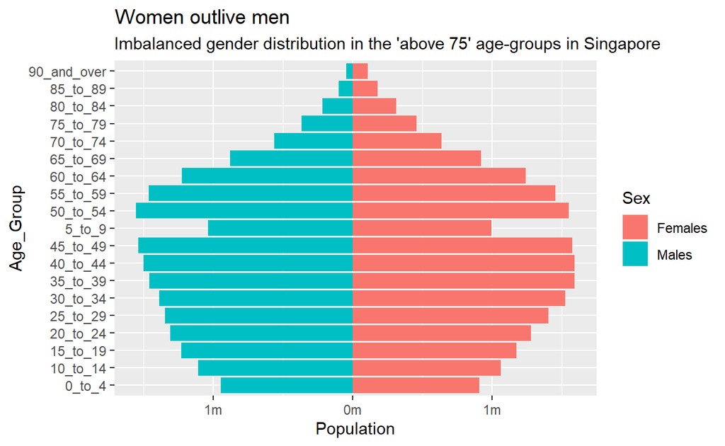

```r
pyramid_pop <- ggplot(agg_pop, aes(x = Age_Group, y = Population, fill = Sex)) +
  geom_bar(data = subset(agg_pop, Sex == "Females"), stat = "identity") +
  geom_bar(data = subset(agg_pop, Sex == "Males"),stat = "identity") +
  scale_y_continuous(labels = paste0(as.character(c(seq(2, 0, -1), seq(1, 2, 1))), "m")) +
  labs(title="Women outlive men", subtitle = "Imbalanced gender distribution in the 'above 75' age-groups in Singapore")+
  coord_flip()

pyramid_pop
```